# Introduction to R and Rstudio

Session - quarto reporting

Zoë Turner

## R Scripts v RMarkdown v Quarto

- Scripts are very quick files of code with comments but RMarkdown and Quarto mix written text with code.
- Quarto is a newer version of RMarkdown (2022) and is very similar for R users.
- Quarto allows the possibility of working with colleagues who use other languages like Python.

## Open a new Quarto file

[figure not shown]

## Render

Will open up a wizard to force the file to be saved.

As Quarto produces an output file it must have rights to save to the location.

## Have a go!

1. Change the title and then render.
2. Go to the bottom of the existing code and in Visual mode create a header `Introduction code` and add a small table.
3. Change the view to Source from Visual - what does the table look like in code?.
4. Click on the wheel icon next to Render and in that menu select Preview in `View Pane`.
5. Render the qmd.

`08:00`

## Code chunks

The code sections in Quarto (and RMarkdown) are called chunks.

These are like smaller R scripts.

## New code chunks

The default is for R chunks in R Studio but chunks can also be Python

````markdown
```{r}
37+9
```
````

## Chunk options

Each `chunk` is a part of a longer script and needs to be run in order to render.

- **Switch off chunks** To stop code running in any of the chunks code:

````markdown
```{r}
#| eval: false

This will not run and break your code
```
````

- **Showing your code** To include code in a report or presentation use `#| echo: true`

## Have a go!

Let’s try to show code in a report:

1. Create an R code chunk and type a sum like `37 * 6`
2. In the chunk add `#| echo: false` under the `{r}` and Render
3. Change the code to `true` and Render

Extra time: Add another line for `#| eval: false`,  
Render, change to `true` and Render

`07:00`

## Global options settings

The default {r} settings are for `echo: true` and `eval: true`.

```r
title: "My report"
format: html
execute:
    echo: true
    eval: true
```

## Self contained

To create an html output that can be emailed without a folder with images and libraries:

```r
title: "My report"
format: html
execute:
    echo: true
    eval: true
embed-resources: true
```

## Report output table of contents

Code can be added to the YAML to create an interactive table of contents (in html)

```r
title: "My report"
format:
  html:
    toc: true
```

Note that spaces in the YAML matter!

## Naming chunks

Chunks can be named which makes them easier to navigate from the bottom left hand menu in the Editor.

`#| label: my-chunk-name`

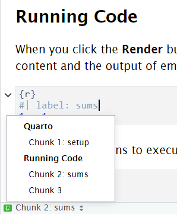

# Navigating headers in RStudio

A headers outline can be switched on/off from the Outline icon in the top right of the Editor pane.

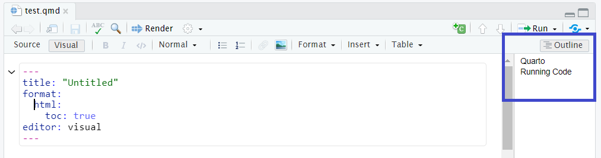